# 3. Results Analysis and Visualization

#### 5.6.1.2 CAMA-1 (Inavolisib x Giredestrant)

🔍 Zoom In for Details

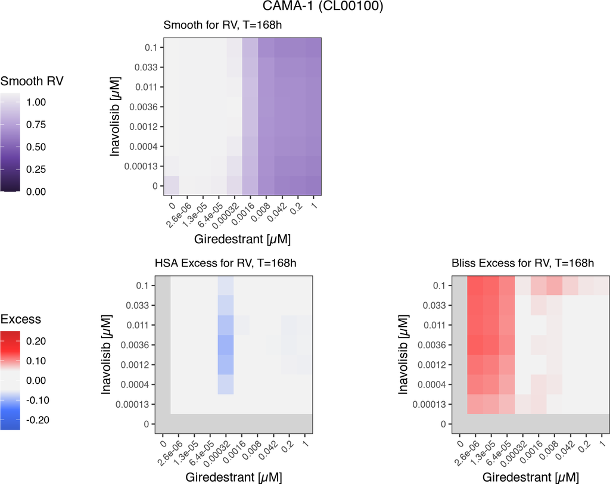

#### 5.6.1.3 EFM-19 (Everolimus x Giredestrant)

🔍 Zoom In for Details

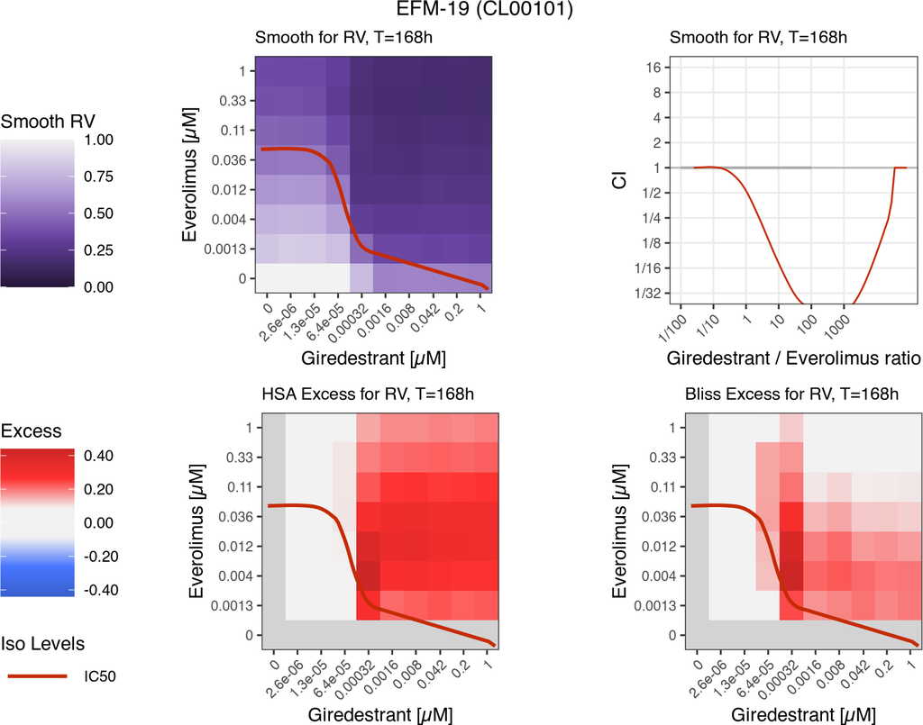

#### 5.6.1.4 EFM-19 (Inavolisib x Giredestrant)

🔍 Zoom In for Details

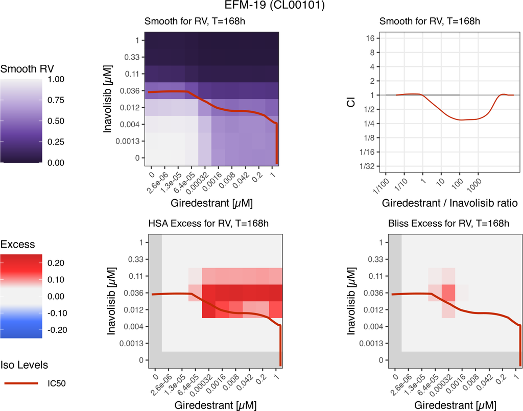

#### 5.6.1.5 MCF-7 (Everolimus x Giredestrant)

🔍 Zoom In for Details

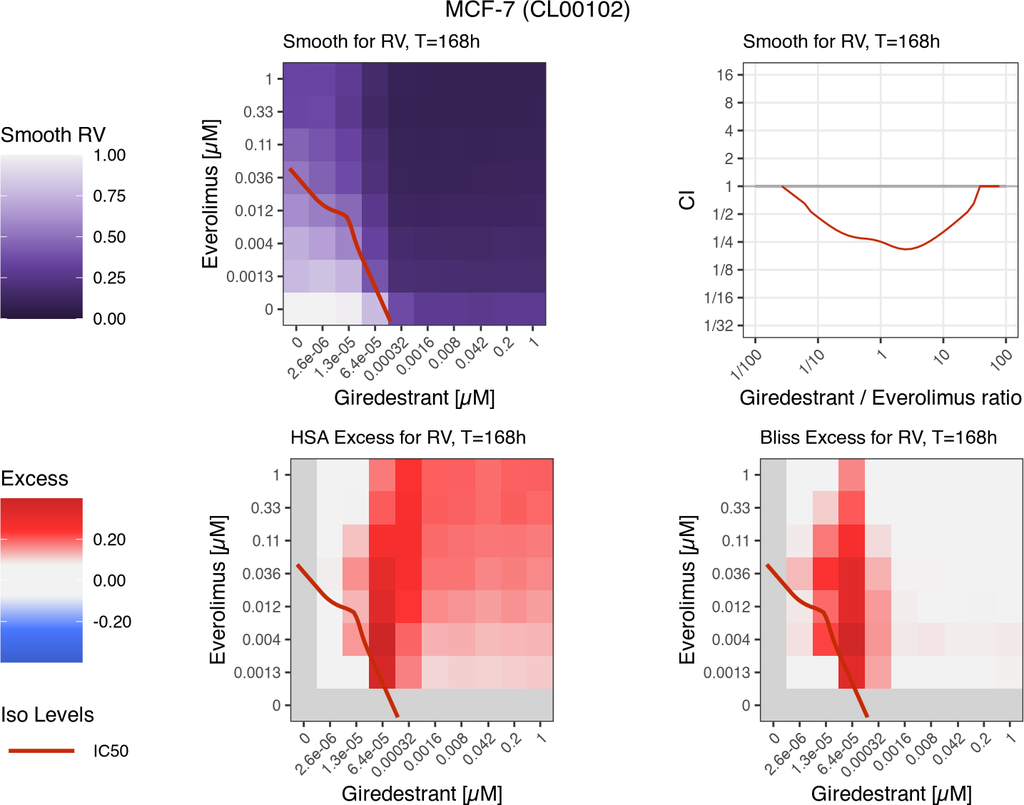

#### 5.6.1.6 MCF-7 (Inavolisib x Giredestrant)

🔍 Zoom In for Details

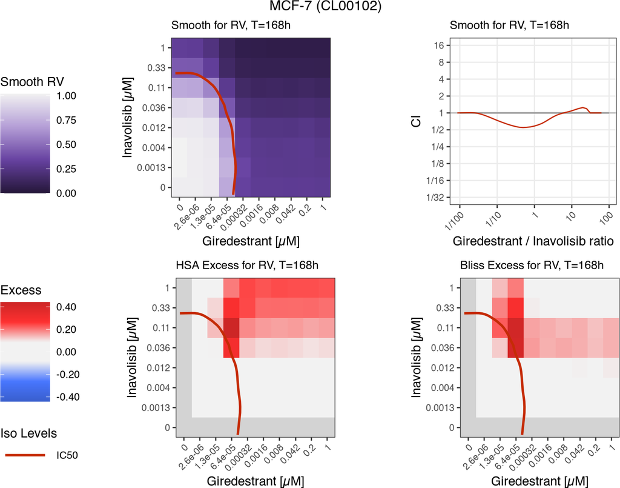

#### 5.6.1.7 T-47D (Everolimus x Giredestrant)

🔍 Zoom In for Details

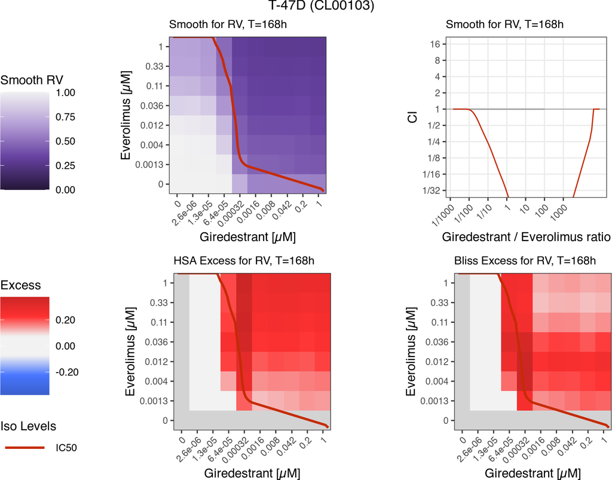

#### 5.6.1.8 T-47D (Inavolisib x Giredestrant)

🔍 Zoom In for Details

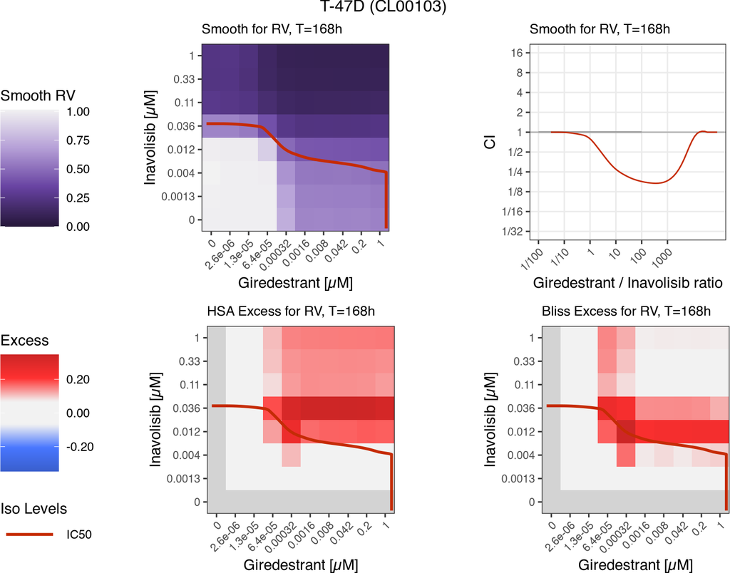

### 5.6.2 GR Value

#### 5.6.2.1 CAMA-1 (Everolimus x Giredestrant)

🔍 Zoom In for Details

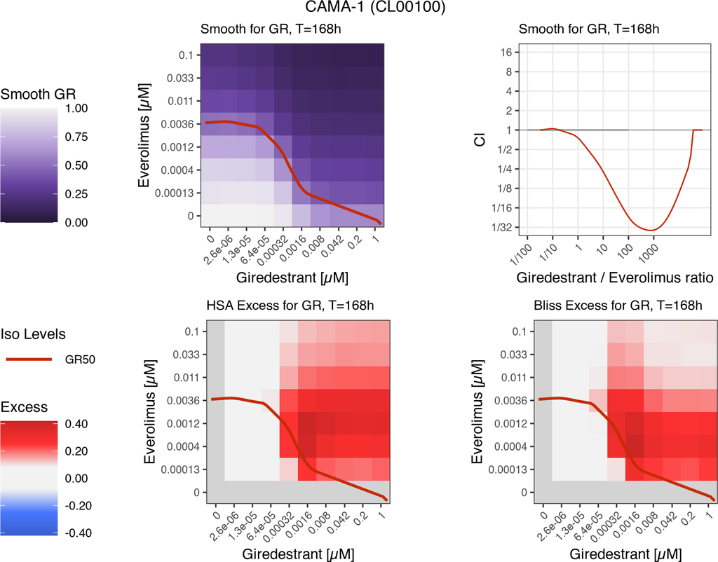

#### 5.6.2.2 CAMA-1 (Inavolisib x Giredestrant)

🔍 Zoom In for Details

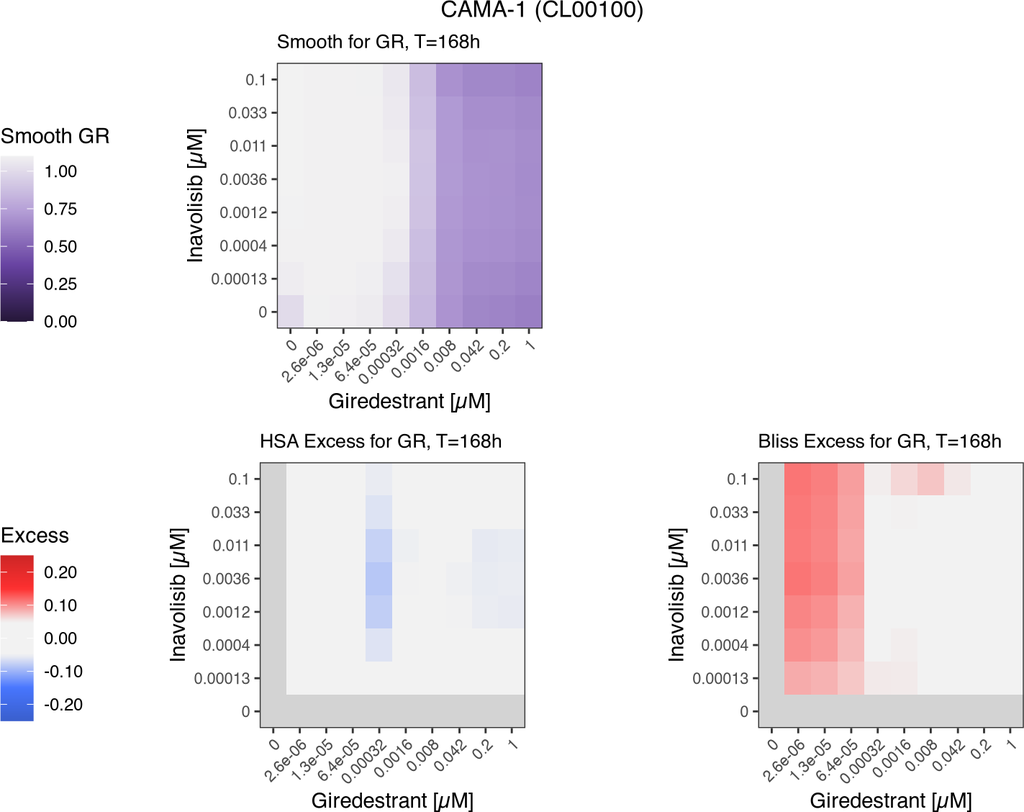

#### 5.6.2.3 EFM-19 (Everolimus x Giredestrant)

🔍 Zoom In for Details

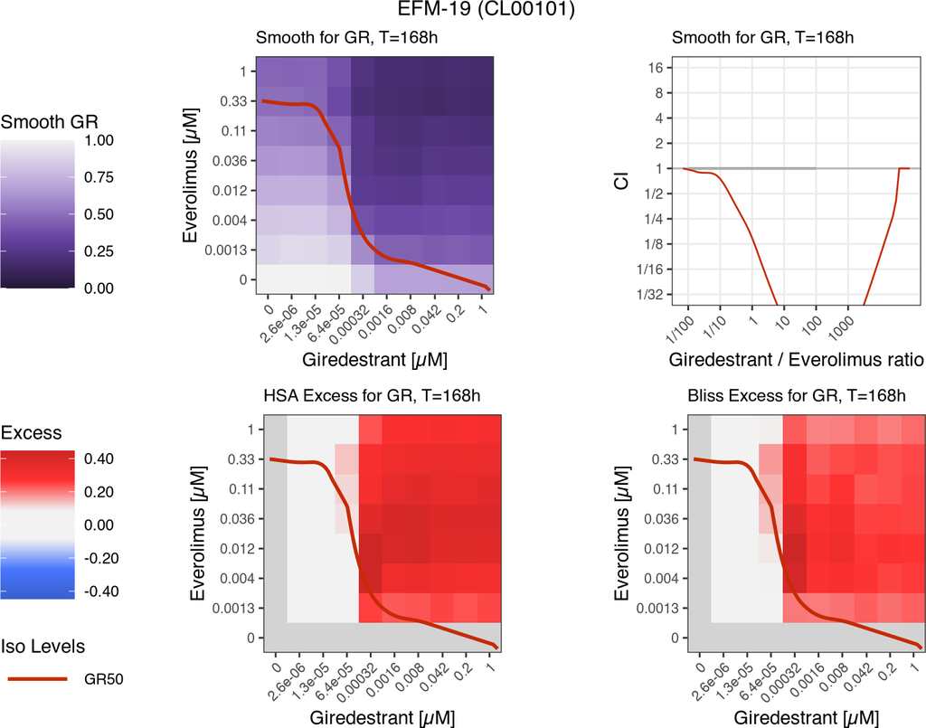